# R Notebook

Import libraries.

```r
library(tximport)
library(GenomicFeatures)
library(readr)
```

Create a conversion from transcripts to gene so that we can evaluate gene expression differences.

```r
txdb <- makeTxDbFromGFF("../data/chr22_genes.gtf")
```

```
Import genomic features from the file as a GRanges object ... OK
Prepare the 'metadata' data frame ... OK
Make the TxDb object ... Warning: The "phase" metadata column contains non-NA values for features of type stop_codon. This
  information was ignored.OK
```

```r
k <- keys(txdb, keytype = "TXNAME")
tx2gene <- select(txdb, keys = k, "GENEID", "TXNAME")
print(tx2gene)
```

| TXNAME | GENEID |
| --- | --- |
| ENST00000424770 | ENSG00000233866 |
| ENST00000398242 | ENSG00000215270 |
| ENST00000609679 | ENSG00000232775 |
| ENST00000440946 | ENSG00000232775 |
| ENST00000414726 | ENSG00000232775 |
| ENST00000423297 | ENSG00000235992 |
| ENST00000422014 | ENSG00000236666 |
| ENST00000435410 | ENSG00000234381 |
| ENST00000426025 | ENSG00000224435 |
| ENST00000440999 | ENSG00000226474 |

[output cut: 990 more lines]

Read in the experimental design matrix to a dataframe. Check the output df.

```r
samples <- read.table("../data/samples.txt", header = TRUE)
print(samples)
```

| sample | condition |
| --- | --- |
| HBR_Rep1 | HBR |
| HBR_Rep2 | HBR |
| HBR_Rep3 | HBR |
| UHR_Rep1 | UHR |
| UHR_Rep2 | UHR |
| UHR_Rep3 | UHR |

Create and store the file path names to be analyzed. Check a sample output.

```r
files <- file.path("../quant", samples$sample, "quant.sf")
print(files[1])
```

```
[1] "../quant/HBR_Rep1/quant.sf"
```

Attach the sample name to each of the quant.sf file names.

```r
names(files) <- paste0(samples$sample)
print(files["HBR_Rep1"])
```

```
                    HBR_Rep1
"../quant/HBR_Rep1/quant.sf"
```

```r
all(file.exists(files))
```

```
[1] TRUE
```

Next we’ll analyze the data at the gene level using our tx2gene object to convert form transcripts to gene-level data.

```r
txi.salmon <- tximport(files, type = "salmon", tx2gene = tx2gene)
```

```
reading in files with read_tsv
1 2 3 4 5 6
transcripts missing from tx2gene: 92
summarizing abundance
summarizing counts
summarizing length
```

```r
head(txi.salmon$counts)
```

```
                HBR_Rep1 HBR_Rep2 HBR_Rep3 UHR_Rep1 UHR_Rep2 UHR_Rep3
ENSG00000008735  412.697  550.000  482.521   25.000   25.000   13.000
ENSG00000015475   73.550   89.514   86.896  117.354   88.031  121.355
ENSG00000025708   23.000   28.000   31.868   61.512   25.286   42.214
ENSG00000025770   83.011   96.144   83.032  225.452  134.780  183.545
ENSG00000040608   74.000   92.999   82.000   18.000   11.000   11.000
ENSG00000054611   37.000   52.727   46.004   80.046   56.574   76.216
```

```r
library(DESeq2)
```

Then we will create our DDS object. We’ll also check the number of reads in each sample.

```r
dds <- DESeqDataSetFromTximport(txi.salmon, samples, ~condition)
dds <- DESeq(dds)
```

```
using 'avgTxLength' from assays(dds), correcting for library size
```

```r
colSums(counts(dds))
```

```
HBR_Rep1 HBR_Rep2 HBR_Rep3 UHR_Rep1 UHR_Rep2 UHR_Rep3
   42597    52414    46514    75528    50197    60051
```

Next we’ll remove any rows that have less than 10 read counts in total.

```r
keep <- rowSums(counts(dds)) >= 10
dds <- dds[keep,]
res <- results(dds)
summary(res)
```

```
out of 601 with nonzero total read count
adjusted p-value < 0.1
LFC > 0 (up)       : 136, 23%
LFC < 0 (down)     : 141, 23%
outliers [1]       : 0, 0%
low counts [2]     : 0, 0%
(mean count < 1)
[1] see 'cooksCutoff' argument of ?results
[2] see 'independentFiltering' argument of ?results
```

Next check the dispersion plot. As counts increase, there should be a decrease to plateau in the dispersion.

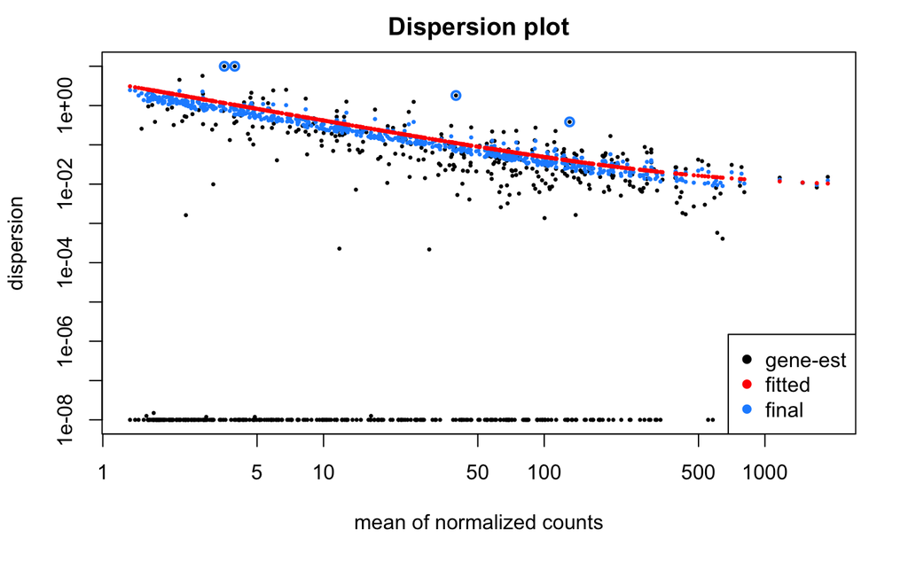

```r
plotDispEsts(dds, main="Dispersion plot")
```

We need to log transform the count data for doing clustering and heatmaps. We use the rlog function as follows.

```r
rld <- rlogTransformation(dds)
head(assay(rld))
```

[output not shown]

The rld object is then used for clustering and generating a heatmap.

```r
#need to replace this code with ggplot2 plots! gplots is deprecated.

library(RColorBrewer)
library(gplots)

(mycols <- brewer.pal(8, "Dark2")[1:length(unique(samples$condition))])
```

```
[1] "#1B9E77" "#D95F02"
```

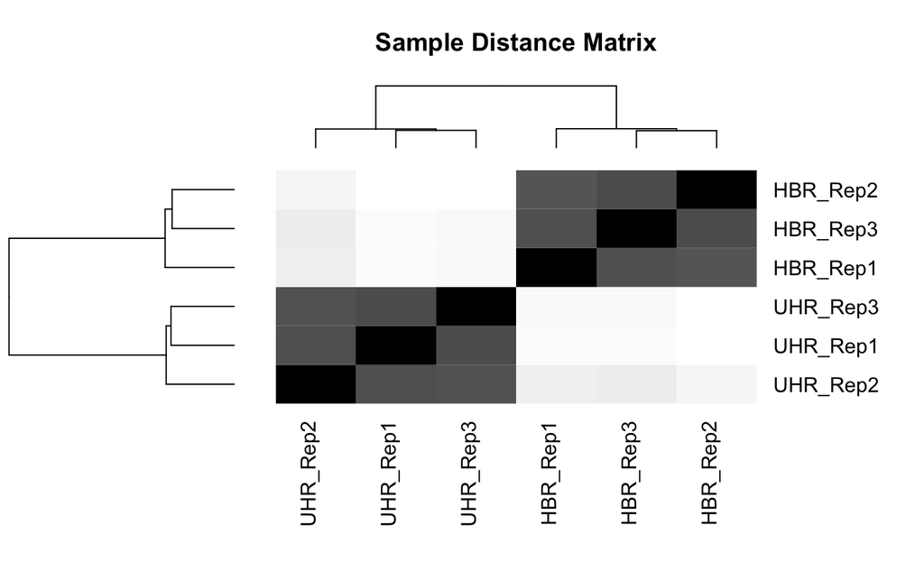

```r
sampleDists <- as.matrix(dist(t(assay(rld))))
heatmap.2(as.matrix(sampleDists), key=F, trace="none",
          col=colorpanel(100, "black", "white"),
          ColSideColors=mycols[samples$condition],
          RowSideColors=mycols[samples$condition],
          margin=c(10, 10), main="Sample Distance Matrix")
```

Make a PCA plot. The HBR and UHR samples should cluster together, respectively. Such clustering indicates there are PCA variables (linear combinations of the existing gene variables) that are able to well-separate the samples based on their origins (which we would expect!). Again, note that we use the log transformed data for PCA analysis.

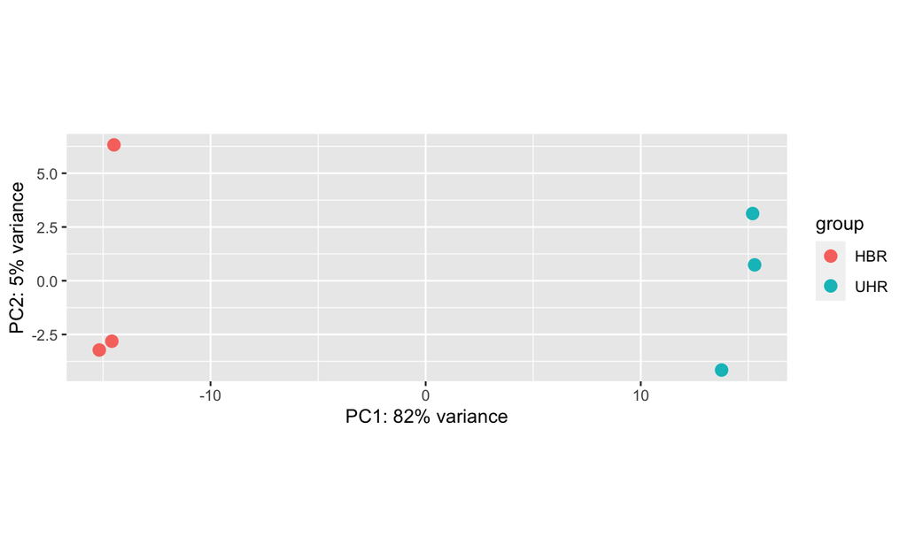

```r
plotPCA(rld, intgroup="condition")
```

Check the p-values:

```r
table(res$padj<0.05)
```

```
FALSE  TRUE
  355   246
```

```r
res <- res[order(res$padj), ]
resdata <- merge(as.data.frame(res), as.data.frame(counts(dds, normalized=TRUE)), by="row.names", sort=FALSE)
names(resdata)[1] <- "Gene"
head(resdata)
```

|  | Gene | baseMean | log2FoldChange | lfcSE | stat | pvalue | padj | HBR_Rep1 | HBR_Rep2 | HBR_Rep3 | UHR_Rep1 | UHR_Rep2 | UHR_Rep3 |
| --- | --- | --- | --- | --- | --- | --- | --- | --- | --- | --- | --- | --- | --- |
| 1 | ENSG00000100167 | 552.8675 | -4.762231 | 0.1723972 | -27.62360 | 5.794793e-168 | 3.482670e-165 | 1023.6762 | 1079.1640 | 1094.9622 | 34.029227 | 42.81593 | 42.557613 |
| 2 | ENSG00000225783 | 498.2435 | -4.587094 | 0.2093588 | -21.91020 | 2.076483e-106 | 6.239831e-104 | 1094.4858 | 903.7909 | 866.5136 | 29.998952 | 57.93660 | 36.734949 |
| 3 | ENSG00000008735 | 323.1766 | -5.313914 | 0.2449555 | -21.69338 | 2.369256e-104 | 4.746409e-102 | 616.8938 | 625.2672 | 647.4625 | 15.050013 | 24.83677 | 9.549058 |
| 4 | ENSG00000128245 | 806.2219 | -2.551961 | 0.1322709 | -19.29344 | 6.097399e-83 | 9.161342e-81 | 1356.6611 | 1526.5335 | 1250.2844 | 250.449084 | 222.39741 | 231.005804 |
| 5 | ENSG00000251322 | 243.7501 | -4.052903 | 0.2137089 | -18.96460 | 3.345655e-80 | 4.021477e-78 | 470.8305 | 464.2386 | 444.8759 | 29.762724 | 22.85918 | 29.933620 |
| 6 | ENSG00000100095 | 285.3363 | -5.223445 | 0.2761609 | -18.91450 | 8.664253e-80 | 8.678693e-78 | 561.1189 | 582.9099 | 518.2667 | 8.870473 | 12.99525 | 27.856558 |

Plot the adjusted p-values as a histogram:

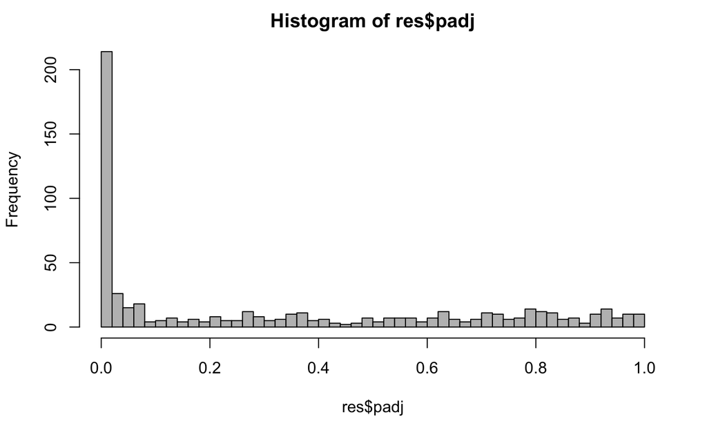

```r
hist(res$padj, breaks=50, col="grey")
```

Make an MA plot:

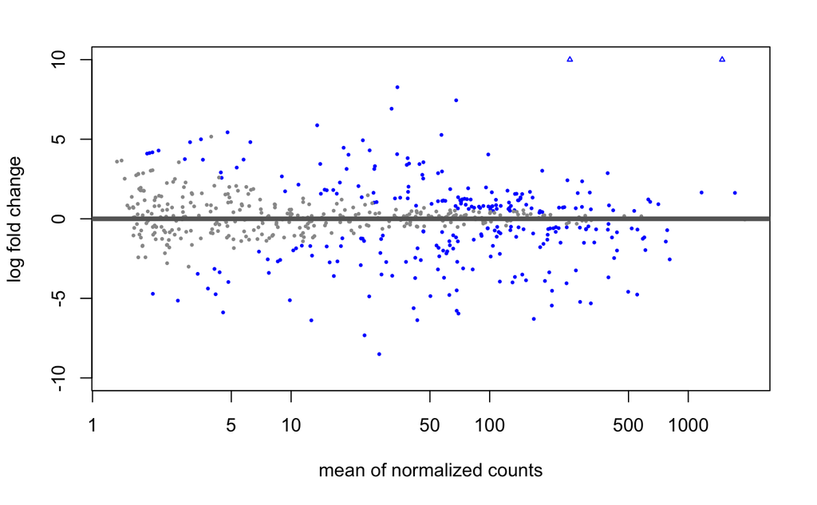

```r
plotMA(res, ylim=c(-10,10))
```

Make a volcano plot:

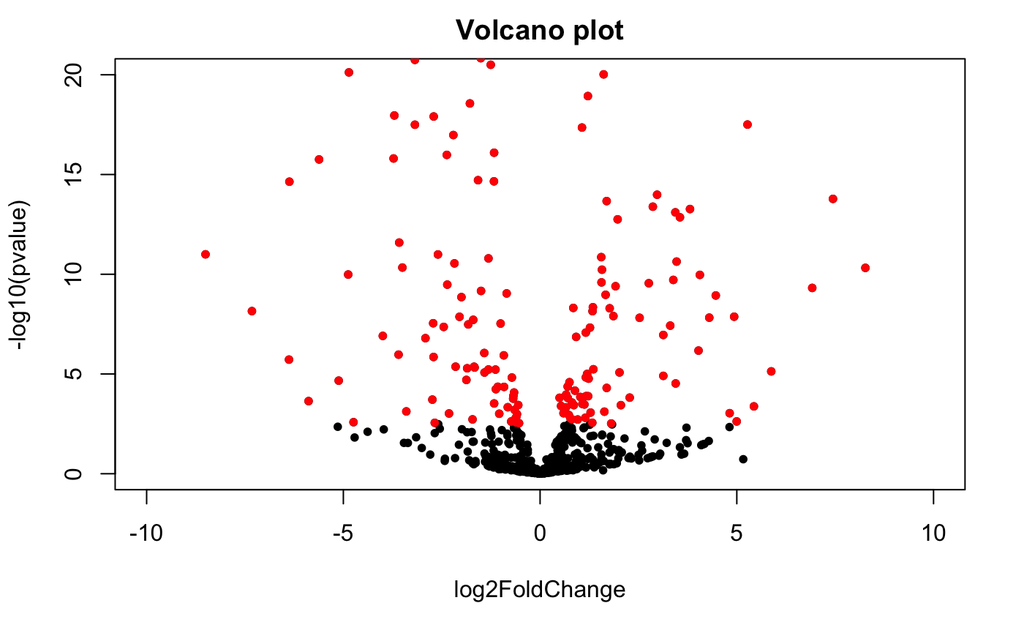

```r
with(res, plot(log2FoldChange, -log10(pvalue), pch=20, main="Volcano plot", xlim=c(-10,10), ylim=c(0,20)))
with(subset(res, padj<.01 ), points(log2FoldChange, -log10(pvalue), pch=20, col="red"))
```

Making a volcano plot using the EnhancedVolcano library.

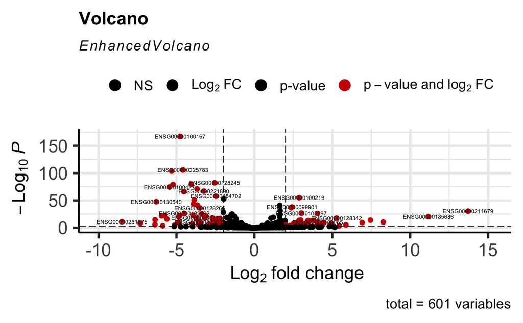

```r
library(EnhancedVolcano)
  EnhancedVolcano(res,
    lab = rownames(res),
    x = 'log2FoldChange',
    y = 'pvalue',
    title = 'Volcano',
    pCutoff = 10e-4,
    FCcutoff = 2,
    pointSize = 2.0,
    labSize = 2.0,
    col=c('black', 'black', 'black', 'red3'),
    colAlpha = 1)
```

Making a volcano plot with ggplot2.

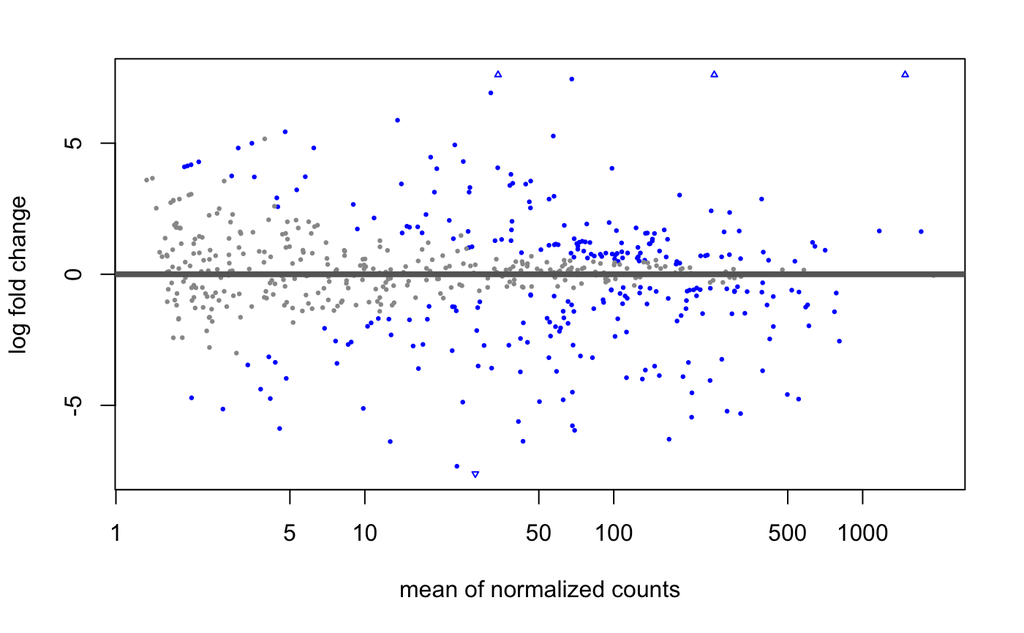

```r
library(tidyverse)
# Create MA plot
plotMA(res)
```

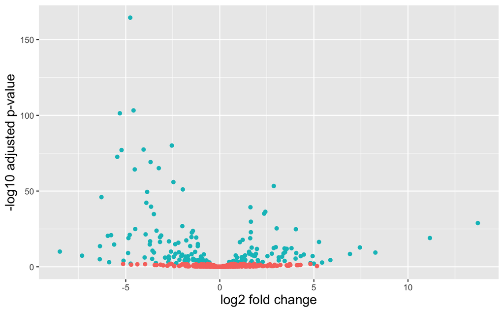

```r
# Generate logical column
res_all <- data.frame(res) %>% mutate(threshold = padj < 0.01)

# Create the volcano plot
ggplot(res_all) +
        geom_point(aes(x = log2FoldChange, y = -log10(padj), color = threshold)) +
        xlab("log2 fold change") +
        ylab("-log10 adjusted p-value") +
        theme(legend.position = "none",
              plot.title = element_text(size = rel(1.5), hjust = 0.5),
              axis.title = element_text(size = rel(1.25)))
```

[figure not shown]

```r
plotCounts(dds, gene=which.min(res$padj), intgroup="condition")
```

```r
resOrdered <- res[order(res$pvalue),]

write.csv(as.data.frame(resOrdered),
          file="condition_treated_results.csv")
```